# Quiz 08

Week 10

Please place your name(s) in the upper-right corner.

1. The text describes how to arrive at the phenomenological competition equations by building on a mechanistic framework with explicit resources. They present a 3-state system of equations for one resource, $R$, and two species that consume it, $N_1$ and $N_2$:
   $$\begin{align}
   \frac{\mathrm{d}R}{\mathrm{d}t} &= rR\left(\frac{K - R - a_1N_1 -
   a_2N_2}{K}\right)\\
   \frac{\mathrm{d}N_1}{\mathrm{d}t} &= b_1N_1R - mN_1\\
   \frac{\mathrm{d}N_2}{\mathrm{d}t} &= b_2N_2R - mN_2
   \end{align}$$
   They then make the assumption that the resources have fast dynamics relative to the consumers: what do they mean by that?
2. Find the two equilibria for $\mathrm{d}R/\mathrm{d}t$. Well, $R^* = 0$ is one, so find the other ;)
3. Replace the $R$ in the equations with the $R^*$ :
   $$\begin{align}
   \frac{\mathrm{d}N_1}{\mathrm{d}t} &= b_1N_1R - mN_1\\
   \frac{\mathrm{d}N_2}{\mathrm{d}t} &= b_2N_2R - mN_2
   \end{align}$$
   Then, arrange each equation so you have three terms: a first-order term of $N_i$, a second-order term of $N_i$, and an interaction term with $N_iN_j$, similar to how we can logistic equation (i.e., $\mathrm{d}N/\mathrm{d}t = rN - r/KN^2$), but with the interaction term at the end.
4. Please identify each equilibrium on the following phase planes for competition (equations below). Additionally, for each equilibrium, label if it’s stable, $s$ or unstable, $u$.
   $$\begin{align}
   \frac{\mathrm{d}N_1}{\mathrm{d}t} &= r_1N_1\left(\frac{K_1 - N_1 -
   \alpha _{12}N_2}{K_1}\right)\\
   \frac{\mathrm{d}N_2}{\mathrm{d}t} &= r_2N_2\left(\frac{K_2 - N_2 -
   \alpha _{21}N_1}{K_2}\right)
   \end{align}$$

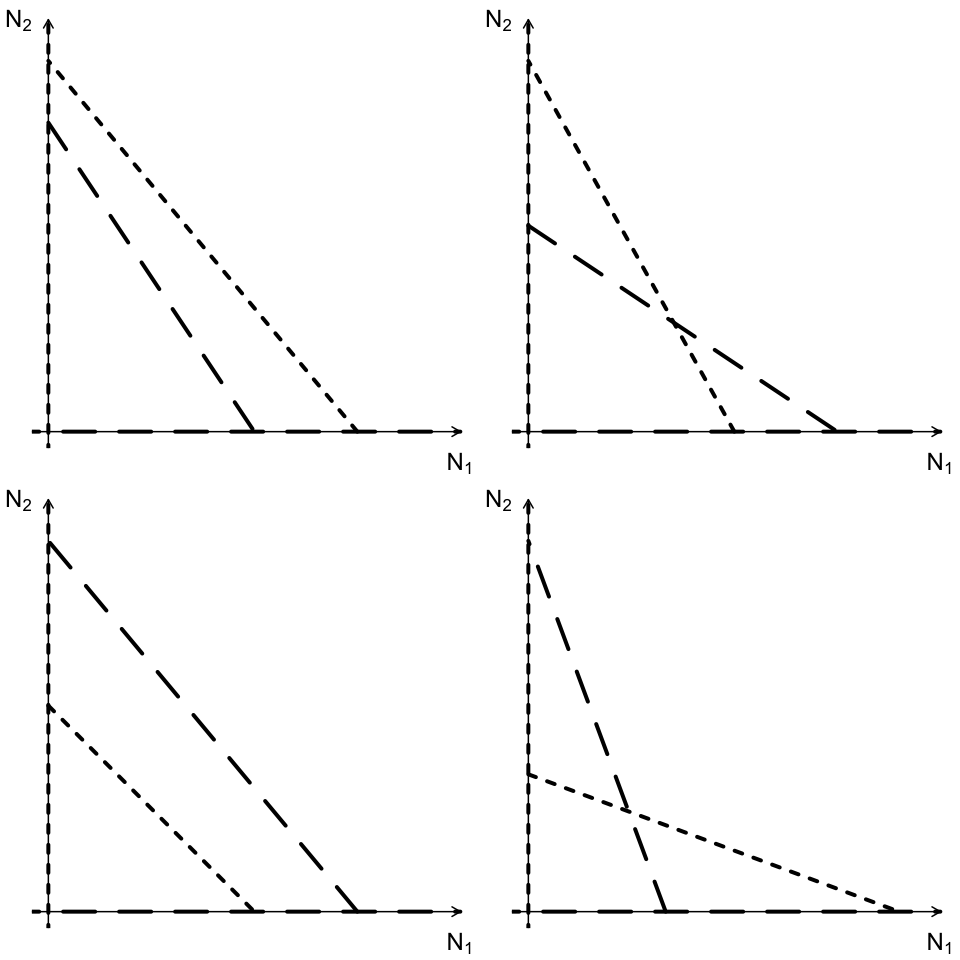